# Dynamic data visualization with R project

Otis Cooper and Stein Dijkstra

2023-01-15

## Goal

A common struggle as a student is trying to find and plan train trips. In order to help us with this task, we developed this dashboard. This dashboard is a first prototype to show what could be possible, but more features need to be added to make it a full alternative to the SNCF website. Our final goal would be to have a website that has all the information for the european train services on one way page, but this prototype is limited in scope to the French rail network.

## Key features

The different pages related to the dashboard will be explained at the bottom of the page but some notable features of our dashboard is: * Interactive search to find the closest station near you

- Update data at each reload, in particular information on Departures time
- Full screen map (not just a minipage)
- Automatic updating of graphtitles and subtitles

## Potential new features

In a future dashboard we would like to add the following features:

- Add in the possibility to schedule and visualize a trip
- Add the possibility to use the map to select a station for the pages on price and departures

## Known bugs

For some addresses, such as “0” the find a station page is known to crash

## Online application

The application can be found at : https://stein-dijkstra.shinyapps.io/RailroadAid_Otis_Stein/

The code can be found at : https://github.com/Trebry/ENSAI_Data_visualization

## Documentation

### Find a station

This tab shows all the different stations in France. Stations offering all the different services offered by SNCF are indicated by green arrows, smaller stations are indicated by orange arrows, and the smallest stations are indicated by red arrows.

When you click on a station you can see the name of the station and also it’s opening hours is available.

In the shinny app you can also search for an address, and the app will pinpoint you to the closet station.

[interactive chart not shown]

### Departures

This tab shows all the departures from a selected station. You can also search the various routes leaving the station using the search bar on the right.

Example of data shown for a departure from Rennes :

```
## # A tibble: 1,901 × 6
##    stop_name date       arrival_time departure_time trip_headsign route_long_n…¹
##    <chr>     <date>     <time>       <time>         <chr>         <chr>
##  1 Rennes    2023-01-15 06:21        06:21          9884          Nord - Bretag…
##  2 Rennes    2023-01-15 07:31        07:31          5332          Bretagne - Su…
##  3 Rennes    2023-01-15 07:47        07:47          8052          Paris - Renne…
##  4 Rennes    2023-01-15 08:16        08:22          7611          ATL-NORD
##  5 Rennes    2023-01-15 09:35        09:35          8054          Paris - Renne…
##  6 Rennes    2023-01-15 10:25        10:32          8605          Paris - Brest…
##  7 Rennes    2023-01-15 10:25        10:29          8707          Paris - Quimp…
##  8 Rennes    2023-01-15 10:30        10:30          5380          Bretagne - Su…
##  9 Rennes    2023-01-15 11:19        11:19          5210          Nord - Bretag…
## 10 Rennes    2023-01-15 11:25        11:25          8005          Paris - Renne…
## # … with 1,891 more rows, and abbreviated variable name ¹route_long_name
```

### Prices

This tab allows you to select a departure station, the class, the minimum and maximum price. When this three criteria have been chosen, the app will display a histogram of the train ticket prices and also a table of the various ticket prices.

An example of data shown for a departure from Rennes, in class 1 at minimum price :

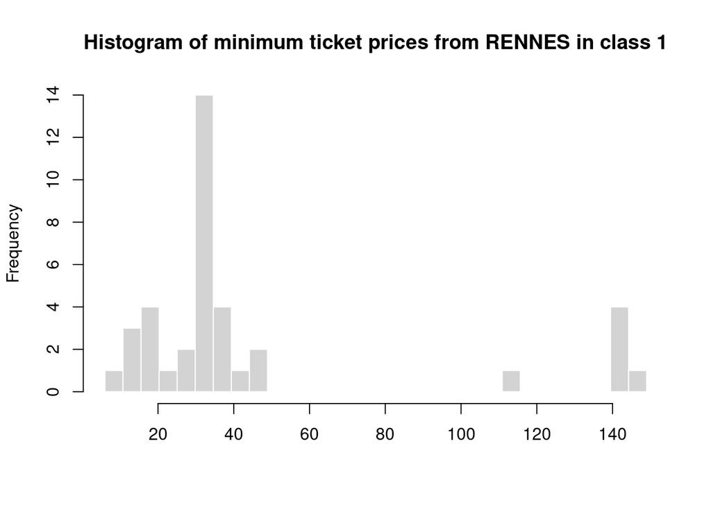

```
## # A tibble: 38 × 9
##    transporteur origine origine…¹ desti…² desti…³ classe profi…⁴ prix_…⁵ prix_…⁶
##    <chr>        <chr>       <dbl> <chr>     <dbl>  <dbl> <chr>     <dbl>   <dbl>
##  1 TGV INOUI    RENNES   87471003 SAVERNE  8.72e7      1 Tarif …    36     232
##  2 TGV INOUI    RENNES   87471003 TGV HA…  8.73e7      1 Tarif …    31     156
##  3 TGV INOUI    RENNES   87471003 TGV HA…  8.73e7      1 Tarif …   114     114
##  4 TGV INOUI    RENNES   87471003 DOUAI    8.73e7      1 Tarif …    31     166
##  5 TGV INOUI    RENNES   87471003 REDON    8.75e7      1 Tarif …    14.6    26.5
##  6 TGV INOUI    RENNES   87471003 QUIMPER  8.75e7      1 Tarif …    30      71
##  7 TGV INOUI    RENNES   87471003 VITRE    8.75e7      1 Tarif …     6      17.5
##  8 TGV INOUI    RENNES   87471003 ST BRI…  8.75e7      1 Tarif …    25.5    25.5
##  9 TGV INOUI    RENNES   87471003 VANNES   8.75e7      1 Tarif …    20      44
## 10 TGV INOUI    RENNES   87471003 VANNES   8.75e7      1 Tarif …    29.5    29.5
## # … with 28 more rows, and abbreviated variable names ¹origine_uic8,
## #   ²destination, ³destination_uic8, ⁴profil_tarifaire, ⁵prix_min, ⁶prix_max
```

### Lost items

This tab shows the various lost items in stations and in trains. The panels is composed of 3 tabs, a tab showing a bar chart of the number of items lost per category, a pie chart showing the percentage of each category of lost items, and final a table showing the details of the lost items>

On the left of the tab, we can choose which lost items to show.

Note this tab, for performance reason only shows 100 lost items.

Example of data shown for lost items :

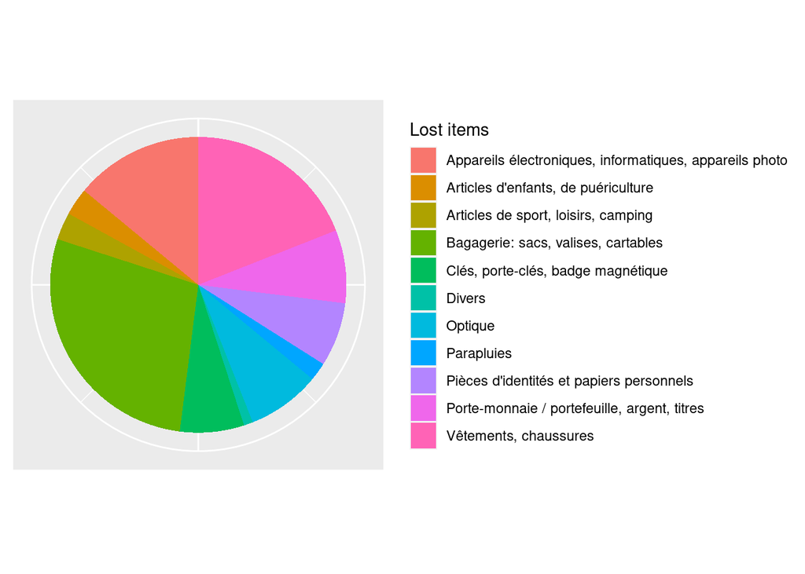

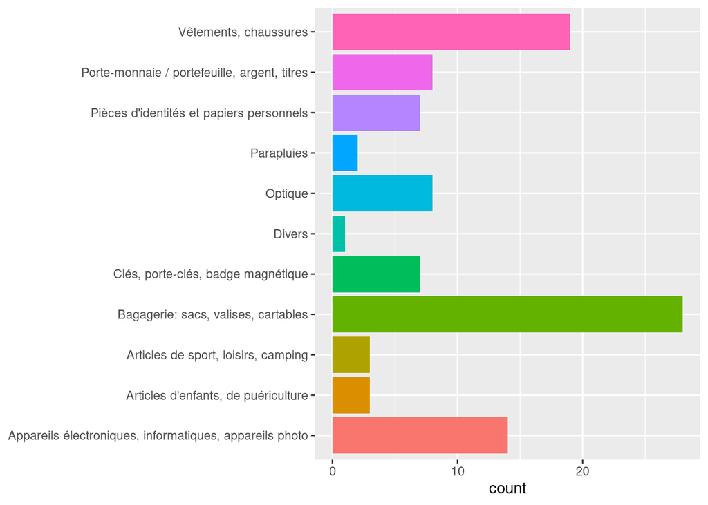